# How Do Weather Conditions Affect Daily TTC Subway Delays in Toronto?

Author

Xiran Yin

# 1 Introduction

Public transit systems play a critical role in urban mobility, supporting large daily ridership and enabling efficient movement across cities. However, system reliability can be affected by a range of factors, including operational disruptions and environmental conditions. Among these, adverse weather—such as heavy precipitation, snowfall, and extreme temperatures—has been widely recognized as a potential source of delays and increased travel-time variability.

In Toronto, the Toronto Transit Commission (TTC) subway system is a key component of daily transportation, making reliability particularly important. While weather is often cited as a contributing factor to transit disruptions, it remains unclear how strongly specific weather conditions are associated with daily delay levels, whether these effects differ across day types, and to what extent weather-based features can be used to predict or classify severe delay days. This study addresses these questions using a combination of statistical analysis and predictive modelling.

The analysis integrates two public datasets:

1. Open-Meteo daily weather records for Toronto.
2. TTC incident-level delay records from Toronto Open Data.

The merged panel spans 2014-01-01 to 2026-01-31 (calendar days: 4414). In the current TTC extract, incident records are present on 4414 of 4414 calendar days, so the modeling sample and the full date panel coincide.

The specific research questions are:

1. How strongly are precipitation and weather severity associated with daily total delay minutes?
2. Do delay levels differ between weekdays and weekends after accounting for weather conditions?
3. Which engineered weather features are most predictive of daily delay minutes?
4. Can we accurately classify whether a day is a **severe delay day** (top quartile of delay minutes)?

The hypotheses are specified in testable null/alternative form: Here, `H0_i` denotes the null hypothesis for research question `i`, and `H1_i` denotes the corresponding alternative hypothesis.

1. **RQ1:** H0_1 = no association between precipitation/severity and daily delay; H1_1 = higher precipitation/severity is associated with higher daily delay.
2. **RQ2:** H0_2 = no weekday/weekend difference after weather controls; H1_2 = weekday and weekend expected delays differ.
3. **RQ3:** H0_3 = engineered weather predictors do not improve predictive fit over baseline; H1_3 = engineered weather predictors improve predictive fit over baseline on the held-out test set.
4. **RQ4:** H0_4 = classification does not outperform random severe-day ranking; H1_4 = at least one model yields ROC-AUC above random.

# 2 Methods

## 2.1 Data Sources

Two data streams were acquired programmatically:

1. **Weather data (Open-Meteo archive API):** Daily weather records for Toronto (requested range: 2014-01-01 to 2026-03-31), including precipitation, snowfall, temperature, and wind variables.
2. **TTC subway delay data (Toronto Open Data CKAN API):** Incident-level delay records across multiple historical CSV/XLS/XLSX resources from package `ttc-subway-delay-data`.

All source calls are made inside `scripts/final_pipeline.py`.  
The weather request extends to 2026-03-31, but the merged analysis ends on 2026-01-31 because TTC incident records currently end there.

## 2.2 Data Wrangling and Feature Engineering

The TTC files use inconsistent column names across years. To address this, the pipeline uses conditional parsing rules:

- **Date-column detection:** candidate columns are scored by name pattern (e.g., `date`, `occ date`) and empirical parse success rate.
- **Delay-column detection:** candidate columns are scored by delay-like names (e.g., `min_delay`) and numeric-validity rate, while non-delay text fields are penalized.
- **Multi-sheet Excel parsing:** for `.xls/.xlsx` resources, all sheets are scanned and parseable sheets are concatenated before aggregation, preventing month-level data loss in multi-tab yearly files.
- **Exception handling and logging:** each CKAN resource is wrapped in `try/except`; failed or skipped resources are logged in `outputs/ttc_resource_pull_log.csv` rather than stopping the pipeline.

After detection, records are standardized to a common incident-level schema:

- `date`
- `min_delay`
- optional `line`, `station` (when available)

Records are filtered to valid numeric delay values and aggregated to daily totals:

- `total_delay_mins` (sum of incident delay minutes)
- `total_incidents` (incident count)
- `median_incident_delay`

The final time window is defined by source overlap: weather is requested through 2026-03-31, while TTC records currently extend through 2026-01-31, so the analysis ends on 2026-01-31. A complete daily calendar is created over this overlap and merged with weather and TTC daily aggregates. The pipeline retains a fallback rule that would code no-incident days as zero-valued delay fields in future data refreshes; in this run, that fallback is not triggered.

The final daily table contains 4414 calendar days from 2014-01-01 to 2026-01-31, of which 4414 have at least one recorded incident and 0 have zero recorded incidents. In this run, annual coverage is complete (100.0% minimum by year), so the incident-recorded subset (4414 days) equals the full panel. All regression, classification, and hypothesis-testing results are still estimated on incident-recorded days by design; with current coverage, this is equivalent to the full date range.

Engineered predictors include:

- `mean_temp_c` (daily average of Open-Meteo `temperature_2m_max` and `temperature_2m_min`)
- `precip_intensity` (Open-Meteo `precipitation_sum / precipitation_hours` when precipitation hours > 0, else 0)
- `weather_type` (Clear / Light Rain-Snow / Heavy Rain-Snow)
- `is_weekend_int` (binary day-type feature: weekday = 0, weekend = 1)
- calendar features (`month_num`, `day_of_week`)

For model training, the numeric feature set is: `precip_mm`, `snowfall_cm`, `gust_speed`, `mean_temp_c`, `precip_intensity`, `is_weekend_int`, and `month_num`.

The three-level weather severity variable is constructed with explicit breakpoints:

- **Clear:** `precip_mm = 0` and `snowfall_cm = 0`
- **Light Rain/Snow:** `precip_mm > 0` or `snowfall_cm > 0`, but not meeting heavy criteria
- **Heavy Rain/Snow:** `precip_mm >= 10` **or** `snowfall_cm >= 5`

These thresholds operationalize weather intensity in interpretable categories for both descriptive tables and model features.

For reproducibility checks, `data/ttc_incidents_sample.csv` stores a random sample of incident records across the full multi-year window (not a first-year-only head).

The classification target is:

- `severe_day = 1` if daily delay is at or above the 75th percentile threshold (180.0 minutes) among incident-recorded days; else `severe_day = 0`.

The 75th-percentile cutoff is used as a pragmatic high-risk threshold for classification; regression results are reported in parallel to avoid over-reliance on a single binary definition of severity.

## 2.3 Data Exploration Tools

Exploratory diagnostics were done with Pandas summary tables (coverage/range checks), Seaborn/Matplotlib static plots (distribution and seasonal structure), and [Plotly interactive visuals](https://xiran-yin.github.io/JSC370final/viz.html) (time-series and weather/day-type comparisons). The exploratory workflow was refined from the midterm implementation documented in midterm_final.html, then updated for the final project’s expanded date range and model comparisons.

## 2.4 Model Choice and Rationale

RQ1–RQ2 are evaluated with descriptive statistics and regression coefficients, while RQ3–RQ4 use supervised prediction. The model set combines interpretable baselines with non-linear learners:

1. **Linear Regression** and **Logistic Regression** provide transparent baseline relationships for continuous and binary outcomes.
2. **Decision Tree** models allow threshold-based interactions (e.g., weather cut points) with straightforward interpretability.
3. **Random Forest** models reduce single-tree variance and generally improve out-of-sample stability.
4. **XGBoost** adds boosted non-linear capacity for potentially complex interactions between precipitation, temperature, and calendar structure.

This structure tests whether added model complexity materially improves held-out accuracy beyond linear baselines.

## 2.5 Modeling Strategy

The modeling workflow maps directly to the research questions: continuous-delay prediction for RQ3 and severe-day classification for RQ4, with shared predictors and identical train/test boundaries for comparability.

### 2.5.1 Regression

Predicting continuous `total_delay_mins` on a 70/30 train-test split:

- Baseline: Linear Regression
- Additional tree models: Decision Tree Regressor, Random Forest Regressor
- Complex boosted model: XGBoost Regressor

Hyperparameters for tree/boosting models were set by constrained validation-oriented tuning (depth, trees, and learning-rate controls), then fixed for final held-out evaluation (e.g., RF `n_estimators=700`, `max_depth=12`; XGBoost `n_estimators=400`, `max_depth=3`, `learning_rate=0.05`).  
Metrics: R², RMSE, and MAE on the held-out test set.

### 2.5.2 Classification

Predicting binary `severe_day` on a stratified 70/30 split:

- Baseline: Logistic Regression (with standardization)
- Additional tree models: Decision Tree Classifier, Random Forest Classifier
- Complex boosted model: XGBoost Classifier

Hyperparameters follow the same validation-first logic (e.g., RF `n_estimators=700`, `max_depth=10`; XGBoost `n_estimators=700`, `max_depth=4`, `learning_rate=0.03`, `eval_metric=AUC`).  
For classification performance, the held-out test set is evaluated with Accuracy, Precision, Recall, F1, and ROC-AUC. Feature-importance diagnostics are reported to show which predictors drive model decisions.  
As a robustness check, five-fold cross-validation was run on incident-recorded days: RF regression reached CV RMSE 96.38 (CV R² 0.032), while classification CV ROC-AUC was 0.584 for Random Forest and 0.597 for Logistic Regression.

Hypothesis decisions are tied to explicit rules: coefficient sign and `p < 0.05` for RQ1–RQ2, held-out RMSE gain for RQ3, and ROC-AUC above 0.5 for RQ4.

# 3 Results

## 3.1 Descriptive Patterns

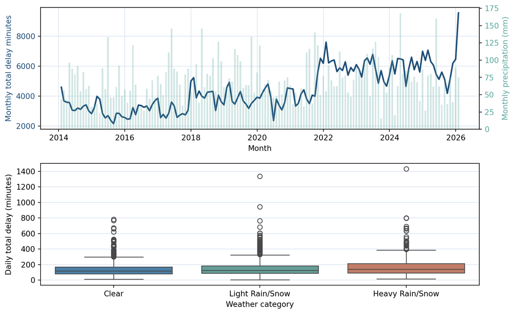

Figure 1: Figure 1. Monthly trend/precipitation (top) and incident-day weather-category delay distribution (bottom).

Figure 1 combines two complementary diagnostics. The top panel shows the monthly trend in total delay minutes with precipitation context, and the bottom panel shows the incident-day delay distribution by weather category. Across 2014-2026, monthly totals are visibly higher in recent years, and the heavy-weather distribution shows both a higher center and a broader upper tail.

Table 1: OLS coefficient summary for daily total delay minutes (incident-recorded days).

|  | term | coef | p | ci_low | ci_high |
| --- | --- | --- | --- | --- | --- |
| 1 | precip_mm | 1.236 | <0.001 | 0.671 | 1.801 |
| 2 | snowfall_cm | 11.168 | <0.001 | 8.612 | 13.724 |
| 3 | mean_temp_c | -0.629 | <0.001 | -0.897 | -0.360 |
| 4 | is_weekend_int | -31.878 | <0.001 | -37.705 | -26.051 |

Figure 1 and the OLS table provide a concise descriptive-to-model bridge. Heavy-weather days average 175.6 minutes versus 136.1 on clear days (ratio 1.29x). The OLS model, estimated on incident-recorded days (n = 4414), shows positive adjusted associations for precipitation (beta = 1.236, p <0.001) and snowfall (beta = 11.168, p <0.001), with lower expected delay on weekends (beta = -31.878).

## 3.2 Model Performance

Table 2: Regression model comparison on the held-out test set.

|  | model | r2 | rmse | mae |
| --- | --- | --- | --- | --- |
| 0 | XGBoost | 0.1042 | 90.0253 | 63.2294 |
| 1 | Random Forest | 0.0931 | 90.5831 | 63.7604 |
| 2 | Linear | 0.0690 | 91.7756 | 63.5696 |
| 3 | Decision Tree | -0.0200 | 96.0628 | 66.6806 |

Table 3: Classification model comparison for severe-delay-day detection on the held-out test set.

|  | model | accuracy | precision | recall | f1 | roc_auc |
| --- | --- | --- | --- | --- | --- | --- |
| 0 | Logistic | 0.5683 | 0.3013 | 0.5482 | 0.3889 | 0.5800 |
| 1 | Random Forest | 0.6619 | 0.3199 | 0.3102 | 0.3150 | 0.5673 |
| 2 | XGBoost | 0.7419 | 0.4306 | 0.0934 | 0.1535 | 0.5664 |
| 3 | Decision Tree | 0.6121 | 0.3013 | 0.4157 | 0.3494 | 0.5625 |

# 4 Conclusions and Summary

## 4.1 Hypothesis Assessment

Using the decision rules in Methods:

RQ1: reject H0_1; precipitation is positively associated with delay (beta = 1.236, p <0.001) and heavy-weather mean delay is 1.29x clear-weather delay.  
RQ2: reject H0_2; weekend coefficient is negative and significant (beta = -31.878, p <0.001), indicating higher weekday expected delay.  
RQ3: reject H0_3 with modest gain; best RMSE improves by 1.91% over linear baseline.  
RQ4: reject H0_4 with moderate effect; best ROC-AUC is 0.58, above random ranking (0.5).

## 4.2 Conclusion

This analysis shows that weather is a meaningful but not dominant driver of daily TTC subway delay risk. Heavier rain/snow days have higher delay levels than clear days, and weekday delay levels are materially higher than weekend levels even after adjustment. At the same time, model performance indicates that weather variables alone do not fully explain daily delay variation, so operational and network factors likely account for additional risk.

From a broader urban-infrastructure perspective, the key implication is planning prioritization: weather-aware service management can improve reliability, but practical forecasting should combine weather signals with operational indicators (e.g., incident type, line-level context, and peak-period load) for stronger day-level performance.

## 4.3 Limitations

1. Open-data resources can be revised over time; rerunning the pipeline on a later snapshot may change historical totals slightly.
2. Daily aggregation masks intra-day structure (peak-hour concentration and line-specific mechanisms).
3. The severe-day definition is percentile-based (180.0 min/day) and therefore operationally useful but not a causal threshold.
4. The model uses weather and calendar predictors only, so unobserved operational factors (e.g., ridership demand, planned service changes, line disruptions) may explain additional variation; findings are therefore associational/predictive rather than causal.